# Pairs Trading

Zach Quicksall

8/5/2020

## Introduction

The subject of pairs trading is a convenient illustration of the application of statistical analysis to a practical domain such as equity investing. The basic principle behind pairs trading is the rationale that companies in the same economic sector, producing the same goods, potentially selling at *similar* pricing, will exhibit similar price movements. As such, we can take advantage of temporary deviations from these integrated movements to capitalize.

To begin, we will simulate two paired securities to illustrate the concept. We will then end by offering additional comments on practical implementation.

## Simulate data

```r
# Set seed
set.seed(2008)

# Length of timeframe
N = 100

# Simulate normal distribution of returns for security x (mean 0, sd 1)
x_returns = rnorm(N, 0, 1)

# Cumulatively sum to generate the final values (add an offset)
x = cumsum(x_returns) + 35

# Similarly, modify x with an offset and some random noise to generate the second security y
y = x + 5 + rnorm(N, 0, 1)

# Create dataframe
returns_df = tibble(time = seq(1, N),
                    x = x,
                    y = y)

# View
kable(head(returns_df)) %>%
  kable_styling(bootstrap_options = "striped", full_width = FALSE)
```

| time | x | y |
| --- | --- | --- |
| 1 | 35.17926 | 40.36146 |
| 2 | 35.09028 | 40.12378 |
| 3 | 35.43238 | 39.80796 |
| 4 | 35.49173 | 41.57664 |
| 5 | 35.81508 | 39.81706 |
| 6 | 35.34915 | 40.05414 |

It is noted that normal distributions do not accurately represent real-world activity. However, they are useful for illustrating the concept. It may be a good exercise to experiment with other sampling distributions.

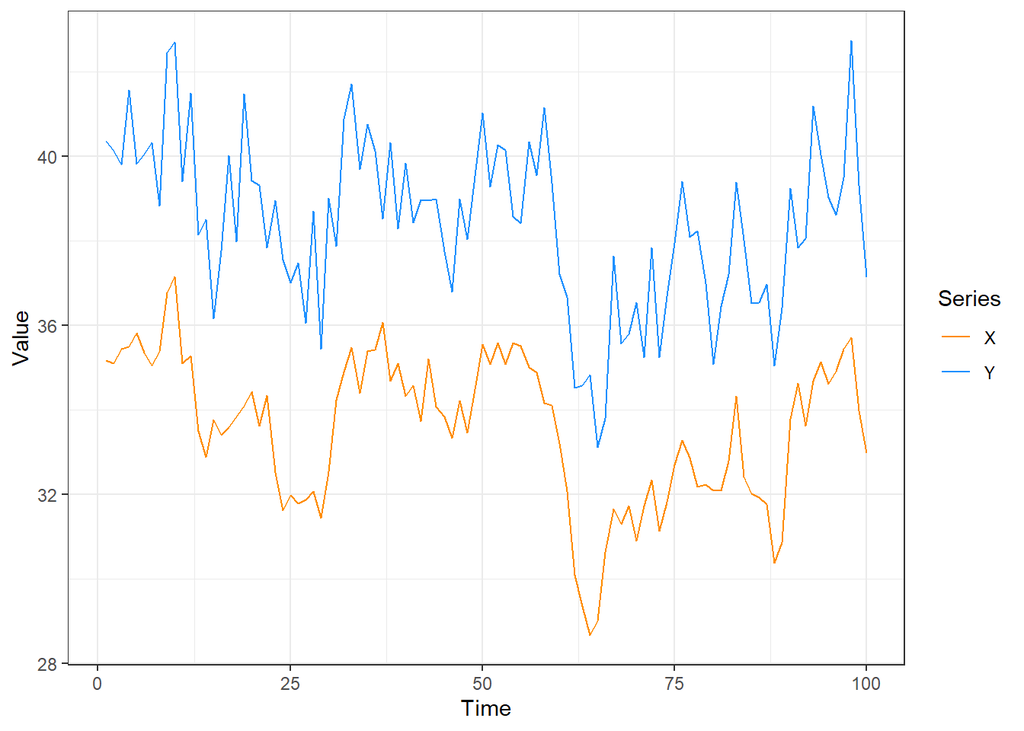

## Cointegration

In typical time series analysis, the mean and variance are assumed constant (stationary) to facilitate the use of common regression tools such as ordinary least squares regression. However, these assumptions do not hold for many biological and economic time series (including equities) and as such cannot be reliably used to make predictions. Fortunately, the concept of cointegration can help with our analysis of non-stationary time series.

Formally, cointegration is a situation where two time series X and Y can be described by the following stationary process: b = Y - aX

In simplified terms, cointegration states that some linear combination of these time series will have a constant mean and variance (i.e. the linear combination **is** stationary). For our application, cointegration essentially guarantees that, at all points in time, some linear combination of our two equities can be represented by a probability distribution. Given the knowledge of this distribution, we can expect our series to follow each others movements quite closely except for situations where we fall to the extremes of that probability distribution (which are likely the result of market errors). We can view this behavior by plotting the difference between our two series:

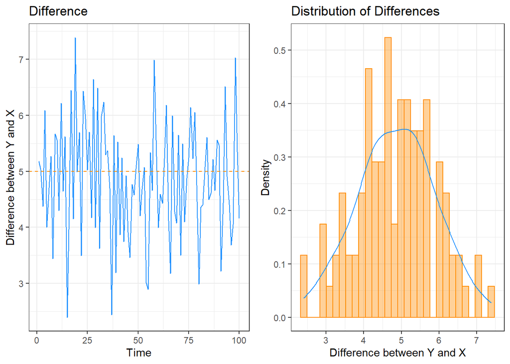

The left-hand plot above shows the spread between the two equities (i.e. the difference) plotted in blue. The horizontal orange line represents the offset (5) we added during data simulation; this is equivalent to the *typical* difference across time. The key takeaway from this figure is that our securities appear to oscillate randomly around a mean. This suggests that our two series are mean-reverting and that any deviations between the securities are likely the result of random noise (indeed, this is the case given our simulations). Moreover, we see through the figure on the right that the distribution of these differences is normal; this is expected given the details of our simulation.

Ultimately, these observations suggest that our securities may be *cointegrated* which is an essential requirement for pairs trading. However, this is just a visual inference. How can we statistically test for the presence of cointegration?

There exist a variety of statistical tests for cointegration. In this notebook We will use the `coint.test` function from the `aTSA` package. We will pick apriori a threshold of 0.01 for our p-value comparison. For more details about this cointegration test, see this Wikipedia [page](https://en.wikipedia.org/wiki/Cointegration#Engle%E2%80%93Granger_two-step_method).

```r
# Perform test
test_result = coint.test(returns_df$x, returns_df$y, d = 0)
```

```
## Response: returns_df$x
## Input: returns_df$y
## Number of inputs: 1
## Model: y ~ X + 1
## -------------------------------
## Engle-Granger Cointegration Test
## alternative: cointegrated
##
## Type 1: no trend
##     lag      EG p.value
##    4.00   -3.77    0.01
## -----
##  Type 2: linear trend
##     lag      EG p.value
##    4.00   -0.37    0.10
## -----
##  Type 3: quadratic trend
##     lag      EG p.value
##   4.000   0.116   0.100
## -----------
## Note: p.value = 0.01 means p.value <= 0.01
##     : p.value = 0.10 means p.value >= 0.10
```

```r
# View output
kable(tidy(test_result)) %>%
  kable_styling(bootstrap_options = "striped", full_width = FALSE)
```

| .rownames | lag | EG | p.value |
| --- | --- | --- | --- |
| type 1 | 4 | -3.7713293 | 0.01 |
| type 2 | 4 | -0.3699903 | 0.10 |
| type 3 | 4 | 0.1163900 | 0.10 |

The above table contains the cointegration test results under three possible assumptions about the relationship between the two series (no trend, linear trend, and quadratic trend). In our case, the simulated series are assumed to not follow any trend (see figure above) and as such we will look at the “Type 1” test statistic. That said, we see that our p-value is less than our pre-determined threshold of 0.01, so these series are likely cointegrated. This supports our assumptions drawn visually from the prior plots.

## Cointegration is not correlation

Before moving forward, it is important to stress that cointegration is **not** the same as correlation. Cointegration can be present *without* correlation and the inverse can also be true. The simulations below illustrate this fact. First, let’s revisit our current pair which are **both** correlated and cointegrated.

### Correlation with cointegration

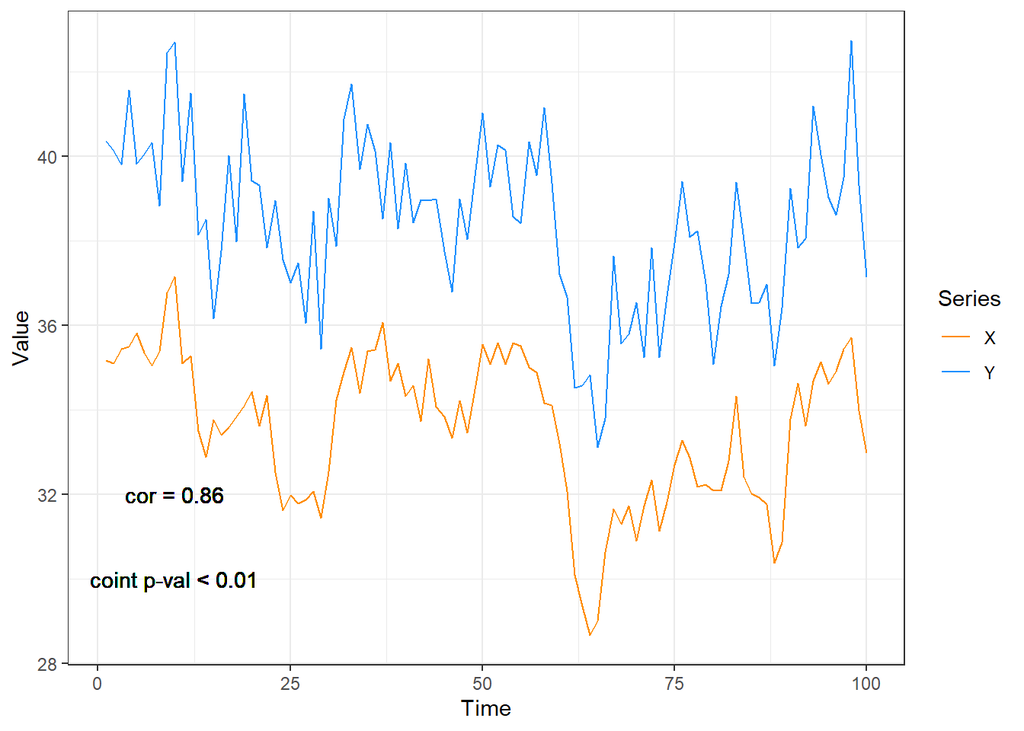

### Correlation without cointegration

Plotted below are two simulated series that exhibit very high correlation but are **not** cointegrated.

```r
# Set seed
set.seed(2008)

# Simulate returns that are correlated but not cointegrated
x = rnorm(100, 1, 1)
y = rnorm(100, 3, 1)
xdiv = cumsum(x)
ydiv = cumsum(y)

# Organize into dataframe
div_df = tibble(time = seq(1,100),
                x = xdiv,
                y = ydiv)
```

The most notable difference between these two series is that they are highly divergent (continue to spread apart over time) which is markedly different from our original data. Furthermore, we see that our series fail the statistical cointegration test but have a *very* high correlation coefficient.

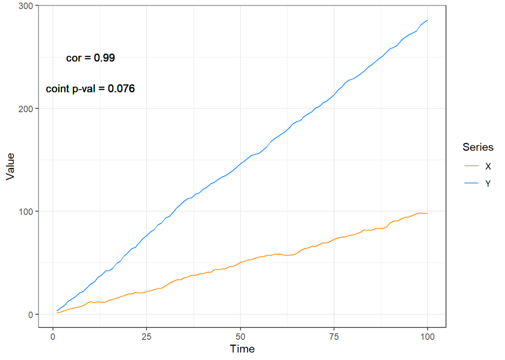

### Cointegration without correlation

Similarly, we simulate data that are cointegrated but **not** correlated. A good theoretical example of this can be found in electrical engineering where the effect of sampling rate can substantially change the representation of a signal. We will compare the correlation and cointegration of a square wave with a fairly large period with that of high-frequency random noise (similar to the background reading on a voltage probe). We can see below that the two series have no correlation with each other but they are, in fact, cointegrated (some linear combination of the square wave and random noise have a static mean and variance).

```r
# Set seed
set.seed(2008)

# Simulate series that are cointegrated but not correlated

## Noise
x = rnorm(1000, 1, 1)

## Square wave
y = rep(c(rep(10,100), rep(-10,100)), 5)

# Organize into dataframe
coint_df = tibble(time = seq(1,1000),
                  x = x,
                  y = y)
```

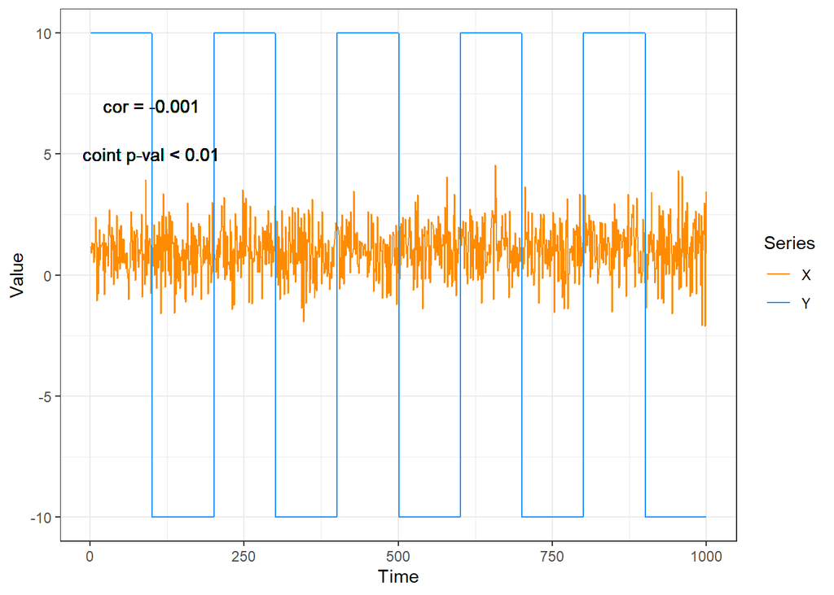

## Connecting cointegration with equities trading

There are a variety of additional considerations regarding the reliability of testing potential equity pairs for cointegration. Repeated testing is susceptible to multiple-comparison bias and will result in spurious “cointegrated” series. Moreover, decisions need to be made regarding selecting a diverse set of cointegrated equities for portfolio construction. These topics alone could take up their own notebooks, and as such will not be discussed in great detail here.

Given the aim of this notebook is to convey the basic principles of pairs trading, the remaining analyses will be performed under the assumption that you have gathered a reliable set of equity pairs for further exploration. To take advantage of these cointegrated pairs, we need to monitor their activity for unusual deviations from the mean. It is during these times that we can enter into short/long positions and then exit as we approach the mean to generate profits.

### The basic methodology

This line of reasoning stems from the definition of cointegration where the stationary process that describes the two series is defined as a *linear combination of the two series*. This “linear combination” is what we are trying to capture when fitting the linear model to predict Y from X. Computing the difference between the raw signal (Y) and the estimated signal (Beta * X) generates our trading signal. It is important to note that this signal exists on an arbitrary scale determined by the pricing of the two series. Rather than having to adjust the decision boundary with a sizable change in price, we will instead compute the z-score of the signal and look at the *relative* difference between the two series. Using this scaled signal, we can define thresholds for trading based on standard deviation.

```r
# Define function to compute zscore
zscore = function(x) {

  zs = (x - mean(x)) / sd(x)
  return(zs)

}

# Compute spread as linear combination of the two equities
fit = lm(y ~ x, data = returns_df)
beta = coef(fit)[1]
diff = returns_df$y - beta * returns_df$x

# Compute zscore of the difference
returns_df = returns_df %>%
  mutate(diff = zscore(diff))
```

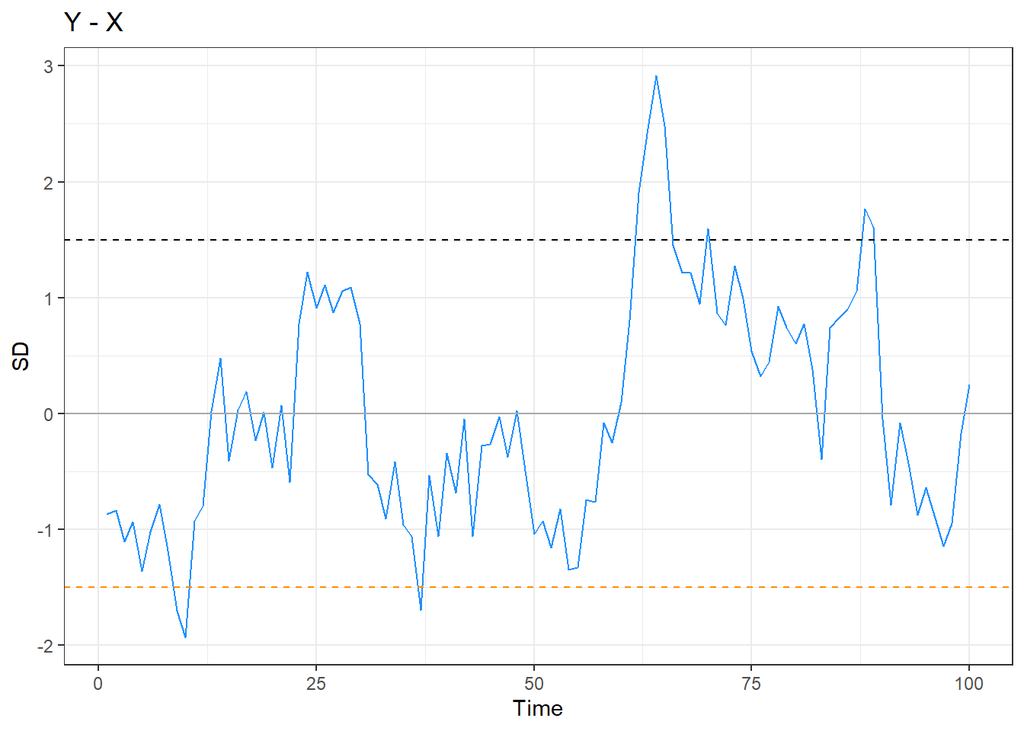

The above plot shows our trading signal. One possible approach would be to go short/long when we exceed 1.5 standard deviations from the mean. As time moves on, we can then close our positions as the signal moves closer to zero (i.e. no deviation from expected pricing).

It is necessary to point out that the trading signal above was generating using *all* of the available data. In reality, we would need to develop a system for making decisions based *solely* on past behavior since we cannot see the future. Additionally, by using the raw signal we are turning a blind eye tot he presense of daily noise which is not a realistic assumption.

### A better approach

To generate a better trading signal, we will use the same principles above, but with a few modifications:

```r
# Fit rolling regression
roll_fit = roll_lm(returns_df$x, returns_df$y, width = 20)

# Extract rolling betas
roll_beta = coef(roll_fit)[, 2]

# Compute difference using rolling betas
roll_diff = returns_df$y - roll_beta * returns_df$x

# Add rolling difference to dataframe
returns_df = returns_df %>%

  # Compute moving mean and variance to generate the final trading signal
  mutate(roll_diff = roll_diff,
         ma1 = roll_mean(roll_diff, width = 1),
         ma20 = roll_mean(roll_diff, width = 20),
         sd20 = roll_sd(roll_diff, width = 20),
         z = ((ma1 - ma20) / sd20))
```

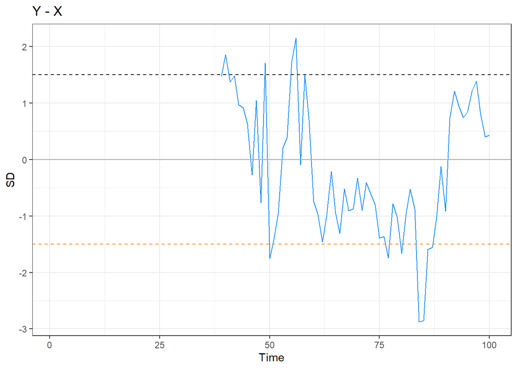

The most visible difference between this signal and the one generated previously is that the signal itself is not present until around the time point 40. This is a result of the rolling regression which requires a sufficient amount of historic data before a non-null model can be fit. This better-represents the true scenario.

Moving beyond the empty portion of the plot, we can see that the signal itself has a very different pattern than that of the original z-score tracing. This is partially due to the use of a rolling regression, but mainly the result of using a moving average to generate the “mean” and “standard deviation” used in computing the z-score. A different-sized moving window would generate a different signal and one could potentially identify a better-sized window that will generate more frequent trading opportunities. However, it is important not to spend too much effort fine-tuning the window size, since this will likely over fit to the available data and not generalize to future behavior.

## Considerations for implementation and use

The above simulations illustrate the theory behind pairs trading. However, implementation of these principles in practice would require making adjustments to address a few important caveats.

First, while a single pair of equities is sufficient for illustrating the concepts, in practice you would need to identify **many** pairs of equities to guard against misguided trades resulting from random noise, changes in industry, general sentiment, or market “love/hate” for individual companies. In searching for these companies, you would need to handle the issue of multiple-testing bias which may result in the identification of falsely-cointegrated pairs. One approach to combat this would be to use a form of p-value adjustment such as false discovery rate. Alternatively, focusing on a particular subset of equities (e.g. only airlines) could help guard against the effect of multiple testing by reducing the total number of tests performed.

In regard to developing a final system for fitting linear models and generating the trading signal, it may be wise to first divide the historic data set into three separate groups for training, validation, and testing. The training data set can be fully utilized for developing algorithms while performance on the validation data set will provide insight into the “best” model configuration. Finally, the testing data set would be used to evaluate the **generalizability** of the algorithm on *future* data before implementing the algorithm in real-time.